# Презентация

Лабораторная работа №2

Калашникова Д. В.

Российский университет дружбы народов, Москва, Россия

25 сентября 2026

# Информация

## Докладчик

- Калашникова Дарья Викторовна
- Студент
- Российский университет дружбы народов
- 1132243108@pfur.ru

[figure not shown]

## Цель работы

Освоить построение простых сетей на коммутаторе и маршрутизаторе, разобрать Ethernet, ARP и ICMP в Wireshark.

## Задание

1. Собрать локальный сегмент из двух VPCS и Ethernet-коммутатора.
2. Настроить IP-адреса и проверить связь ping.
3. Включить захват пакетов на линии PC1 — коммутатор.
4. Разобрать ARP и ICMP в Wireshark.
5. Заменить второй VPCS на FRR.
6. Проверить доступность шлюза с PC1.
7. Заменить FRR на VyOS.
8. Сравнить поведение FRR и VyOS.

## Локальный сегмент в GNS3

Два VPCS соединены через один Ethernet-коммутатор.

[figure not shown]

Локальный сегмент в GNS3

## Настройка PC1

Задан адрес 192.168.1.11/24, шлюз 192.168.1.1.

[figure not shown]

Настройка PC1

## Настройка PC2

Задан адрес 192.168.1.12/24 с тем же шлюзом.

[figure not shown]

Настройка PC2

## Проверка связи ping

Пять откликов с TTL 64 — коммутация работает.

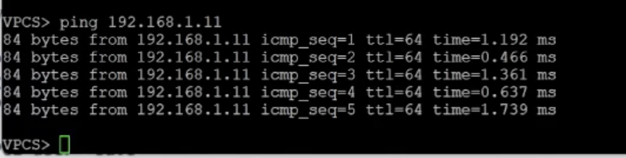

Проверка ping

## Захват на линии PC1 — коммутатор

Запущен перехват пакетов на выбранном участке.

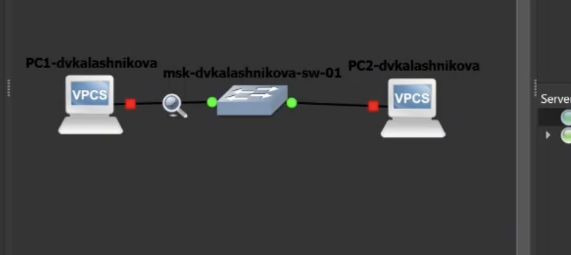

Захват пакетов

## Широковещательные ARP-запросы

Кадры идут на ff:ff:ff:ff:ff:ff — MAC получателя пока неизвестен.

[figure not shown]

ARP-запросы

## Разбор ICMP Echo Request

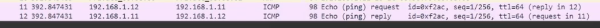

ICMP Echo Request

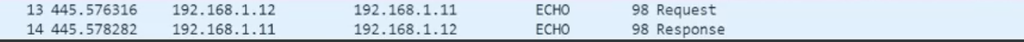

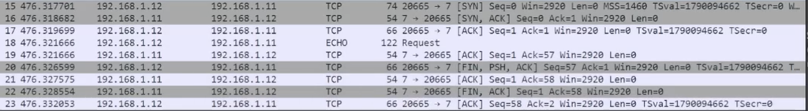

## Замена второго VPCS на FRR

Теперь проверяется и доступ PC1 к шлюзу.

[figure not shown]

FRR вместо VPCS

## Повторная настройка PC1

Адрес 192.168.1.10/24, шлюз 192.168.1.1.

[figure not shown]

Повторная настройка PC1

## Конфигурация FRR

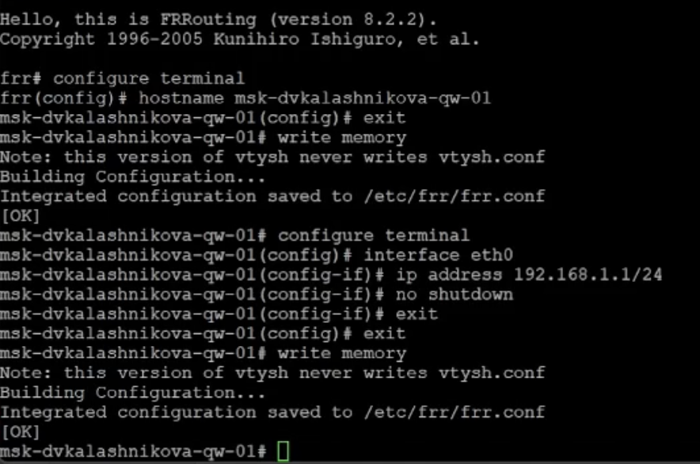

Конфигурация FRR

## Состояние eth0

Интерфейс up с адресом 192.168.1.1/24.

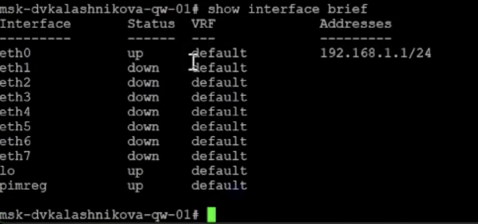

Состояние eth0

## Ping шлюза с PC1

Все запросы получили ответы — линия до FRR исправна.

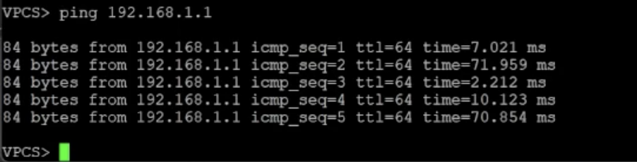

Ping шлюза

## ICMP-трафик на линии к FRR

Запросы от 192.168.1.10 и ответы от 192.168.1.1.

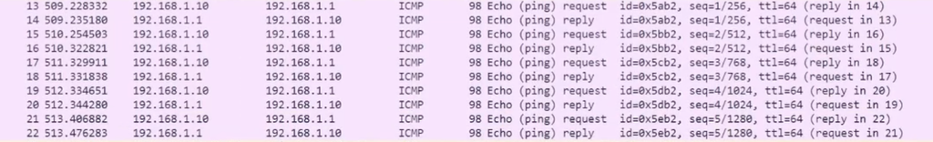

ICMP на линии к FRR

## Схема с FRR в работе

Зелёные точки — интерфейсы подняты.

[figure not shown]

Схема с FRR

## Контроль show ip на PC1

Адрес 192.168.1.10/24 и шлюз 192.168.1.1 перед заменой.

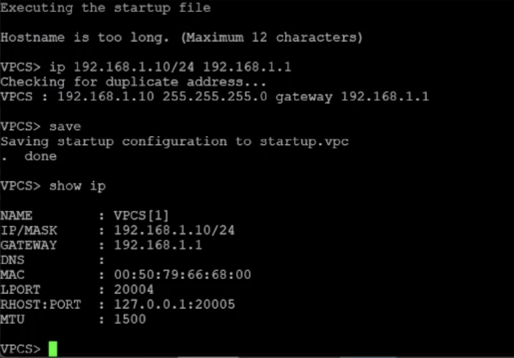

show ip на PC1

## Настройка VyOS

Удалён DHCP, задан статический 192.168.1.1/24 на eth0.

[figure not shown]

Настройка VyOS

## Проверка VyOS после commit

eth0 в состоянии up с адресом 192.168.1.1/24.

[figure not shown]

Проверка VyOS

## Ping шлюза через VyOS

Результат совпадает с FRR — логика IPv4 не меняется.

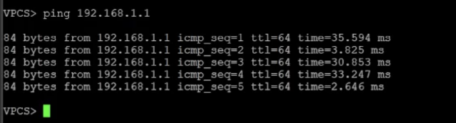

Ping через VyOS

## ICMP-обмен PC1 ↔︎ VyOS

Wireshark показывает запросы и ответы между 192.168.1.10 и 192.168.1.1.

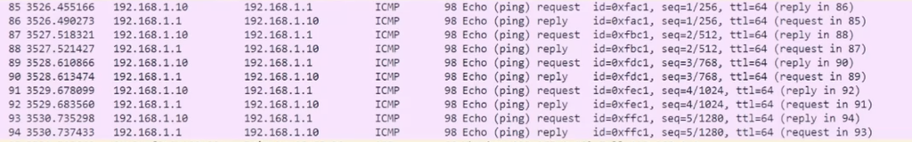

ICMP с VyOS

## Выводы

Освоено построение простых схем на коммутаторе и маршрутизаторе. Изучено поведение Ethernet, ARP и ICMP в Wireshark. Стенд работает корректно.